# AFDMD-111 Estadística

Subindexado de datos y gráficas

Armando Patricio Piña Canul

11/09/2023

# Subindexado de vectores atómicos

El subindexado de vectores atómicos permite obtener partes de un vector atómico (los primeros elementos, los 10 últimos, etc.) y es útil en muchos tipos de análisis que suceden en diversas ramas de la ciencia. Supongamos que tenemos lo siguiente:

```r
dnormales <- rnorm(20)    # 10 numeros aleatorios de una dist. normal
dnormales   # Imprimimos el vector
```

```
 [1]  0.8497548  0.0157300  0.3556367 -0.3154340  2.0554794  1.8344251
 [7] -0.8053794 -1.8466779 -0.1491702 -0.1307761 -0.1868416  0.4766108
[13] -0.6721750 -0.9086165  0.1426726 -0.6867162  1.6434904 -0.4500743
[19]  0.3545437  0.6676993
```

## Ejercicios:

1.- ?Cuál es el resultado de `dnormales[order(x)]`, `dnormales[1:length(vec)]`, `dnormales[-20]`, `dnormales[vec>0.5]`?

```r
set.seed(123)
dnormales <- rnorm(20)
resultado_1 <- dnormales[order(dnormales)]
resultado_2 <- dnormales[1:length(dnormales)]
resultado_3 <- dnormales[-20]
resultado_4 <- dnormales[dnormales > 0.5]
print(resultado_1)
```

```
 [1] -1.96661716 -1.26506123 -0.68685285 -0.56047565 -0.55584113 -0.47279141
 [7] -0.44566197 -0.23017749  0.07050839  0.11068272  0.12928774  0.35981383
[13]  0.40077145  0.46091621  0.49785048  0.70135590  1.22408180  1.55870831
[19]  1.71506499  1.78691314
```

```r
print(resultado_2)
```

```
 [1] -0.56047565 -0.23017749  1.55870831  0.07050839  0.12928774  1.71506499
 [7]  0.46091621 -1.26506123 -0.68685285 -0.44566197  1.22408180  0.35981383
[13]  0.40077145  0.11068272 -0.55584113  1.78691314  0.49785048 -1.96661716
[19]  0.70135590 -0.47279141
```

```r
print(resultado_3)
```

```
 [1] -0.56047565 -0.23017749  1.55870831  0.07050839  0.12928774  1.71506499
 [7]  0.46091621 -1.26506123 -0.68685285 -0.44566197  1.22408180  0.35981383
[13]  0.40077145  0.11068272 -0.55584113  1.78691314  0.49785048 -1.96661716
[19]  0.70135590
```

```r
print(resultado_4)
```

```
[1] 1.5587083 1.7150650 1.2240818 1.7869131 0.7013559
```

2.- ?Qué sucede si hacemos `dnormales[0:3]`? ?Cuál es la longitud del vector?

```r
dnormales[0:3]
```

```
[1] -0.5604756 -0.2301775  1.5587083
```

3.- Ahora suponga que `x <- c(1,24,8)` y `uno <- c(T,T,F)`. ?Qué sucede si hacemos `x[uno]`? ?Y si hacemos `x[as.double(uno)]`?

```r
x <- c(1,24,8)
uno <- c(T,T,F)

x[uno]
```

```
[1]  1 24
```

```r
x[as.double(uno)]
```

```
[1] 1 1
```

#### Nota

> Puede referirse a las [diapositivas](https://monoxide2000.github.io/slidesUQroo2)

# Subindexado de listas

Las listas se pueden subindexar mediante los operadores `[`, `[[` y `$`. Recordemos que cuando indexamos con `[`, el resultado siempre es del mismo tipo. Ahora suponga que tenemos la siguiente lista:

```r
listaPrueba <- list(Mayusculas = LETTERS[1:15], Ciudades = c("Cancun", "Playa", "Chetumal", "Merida"), casos = list(a=23, b= 1:8, c=list(d=1,e=TRUE)))
str(listaPrueba)
```

```
List of 3
 $ Mayusculas: chr [1:15] "A" "B" "C" "D" ...
 $ Ciudades  : chr [1:4] "Cancun" "Playa" "Chetumal" "Merida"
 $ casos     :List of 3
  ..$ a: num 23
  ..$ b: int [1:8] 1 2 3 4 5 6 7 8
  ..$ c:List of 2
  .. ..$ d: num 1
  .. ..$ e: logi TRUE
```

Ejercicios (en base al objeto `listaPrueba`),

1.- ?Con qué comando puedo obtener la lista casos?

```r
listaPrueba$casos
```

```
$a
[1] 23

$b
[1] 1 2 3 4 5 6 7 8

$c
$c$d
[1] 1

$c$e
[1] TRUE
```

2.- ?Cómo puedo obtener el único valor lógico de `listaPrueba`?

```r
listaPrueba$casos$c$e
```

```
[1] TRUE
```

```r
listaPrueba[[3]]$c[[2]]
```

```
[1] TRUE
```

```r
listaPrueba$casos[[3]][[2]]
```

```
[1] TRUE
```

4.- ?Cuál es la diferencia entre `listaPrueba[1]` y `listaPrueba[[1]]`? La diferencia esta en el resultado que se tiene.

5.- ?Cómo puedo obtener el objeto `"Chetumal"`?

```r
listaPrueba$Ciudades[3]
```

```
[1] "Chetumal"
```

6.- ?Cómo puedo obtener el tercer elemento de `b`?

```r
listaPrueba$casos$b[[3]]
```

```
[1] 3
```

# Indexado de matrices

Suponga que tenemos la matriz:

```r
matriz1 <- matrix(rnorm(20), nrow=5)
dim(matriz1)
```

```
[1] 5 4
```

## Ejercicios:

A partir de `matriz1`, hallar:

1.- La matriz que consta de las primeras dos columnas de `matriz1`.

```r
matriz_primera_dos_columnas <- matriz1[, 1:2]
dim(matriz_primera_dos_columnas)
```

```
[1] 5 2
```

2.- La matriz que consta de las primeras dos filas y dos columnas de `matriz1`.

```r
matriz_primeras_dos_filas_dos_columnas <- matriz1[1:2, 1:2]
dim(matriz_primeras_dos_filas_dos_columnas)
```

```
[1] 2 2
```

3.- La matriz que consta del elemento $a_{2,3}$ de `matriz1`

```r
elemento_a_2_3 <- matriz1[2, 3]
dim(elemento_a_2_3)
```

[output not shown]

4.- ?Son equivalentes los comandos `matriz1[c(1,2),c(3,4)]` y `matriz1[1:2,c(3,4)]`? (tip: puede probar con el comando `identical`)

```r
identical(matriz1[c(1,2), c(3,4)], matriz1[1:2, c(3,4)])
```

```
[1] TRUE
```

# Subindexado de `data.frame`

El subindexado de `data.frames` es similar al subindexado por medio de listas y matrices. En este caso nos concentraremos en el paquete `dplyr` que permite manipular `data.frames`. Cualquier paquete en `R` se puede instalar mediante el comando `install.packages(<nombre.paquete>)`, por ejemplo para instalar `dplyr` hacemos:

```r
install.packages("dplyr", dependencies = TRUE)   # instalo el paquete
library(dplyr)         # Cargo el paquete para trabajar con sus funciones
```

## Tarea:

1.- Investigar para qué sirve el paquete `dplyr`.

El paquete dplyr en R es una parte fundamental del conjunto de paquetes conocido como “tidyverse”. dplyr proporciona un conjunto coherente y eficiente de funciones para manipulación y transformación de datos en R. Está diseñado para trabajar con marcos de datos de una manera intuitiva y eficiente, facilitando las tareas comunes de manipulación de datos.

2.- ?Cuáles son los comandos importantes del paquete `dplyr`?

Algunas de las funciones clave proporcionadas por dplyr incluyen:

- `select()`: Para seleccionar columnas específicas de un marco de datos.
- `filter()`: Para filtrar filas basadas en condiciones específicas.
- `arrange()`: Para ordenar filas por ciertas variables.
- `mutate()`: Para agregar nuevas columnas o transformar las existentes.
- `summarise()`: Para resumir datos y calcular estadísticas descriptivas.
- `group_by()`: Para agrupar datos por una o más variables.
- `join()`: Para combinar dos marcos de datos basándose en condiciones específicas.

3.- Supongamos que tenemos un `data.frame` `df <- data.frame(a=1:8, letras =letter[1:8])`, qué sucede si aplico `select(df, a)`. ?Y si aplico `filter(df, a<5)`?

```r
df <- data.frame(a = 1:8, letras = letters[1:8])
select(df, a)
```

```
  a
1 1
2 2
3 3
4 4
5 5
6 6
7 7
8 8
```

```r
filter(df, a<5)
```

```
  a letras
1 1      a
2 2      b
3 3      c
4 4      d
```

# Gráficos de funciones bidimensionales

Los gráficos permiten mostrar múltiples características de una función. Los máximos, mínimos, etc., son métricas que nos dicen mucho acerca del comportamiento de una función. `R` nos permite graficar funciones de manera sencilla utilizando el concepto de vector. Por ejemplo, quizás estemos interesados en conocer la forma de onda de la función seno acotada, la cual se define matemáticamente mediante la siguiente fórmula:

$$f(t) = \begin{cases}
\sin(2 \pi t) & \mbox{para} -1 < t < 1\\
0 & \mbox{resto}.
\end{cases}$$
Y la cual en `R` se graficar? de la siguiente manera:

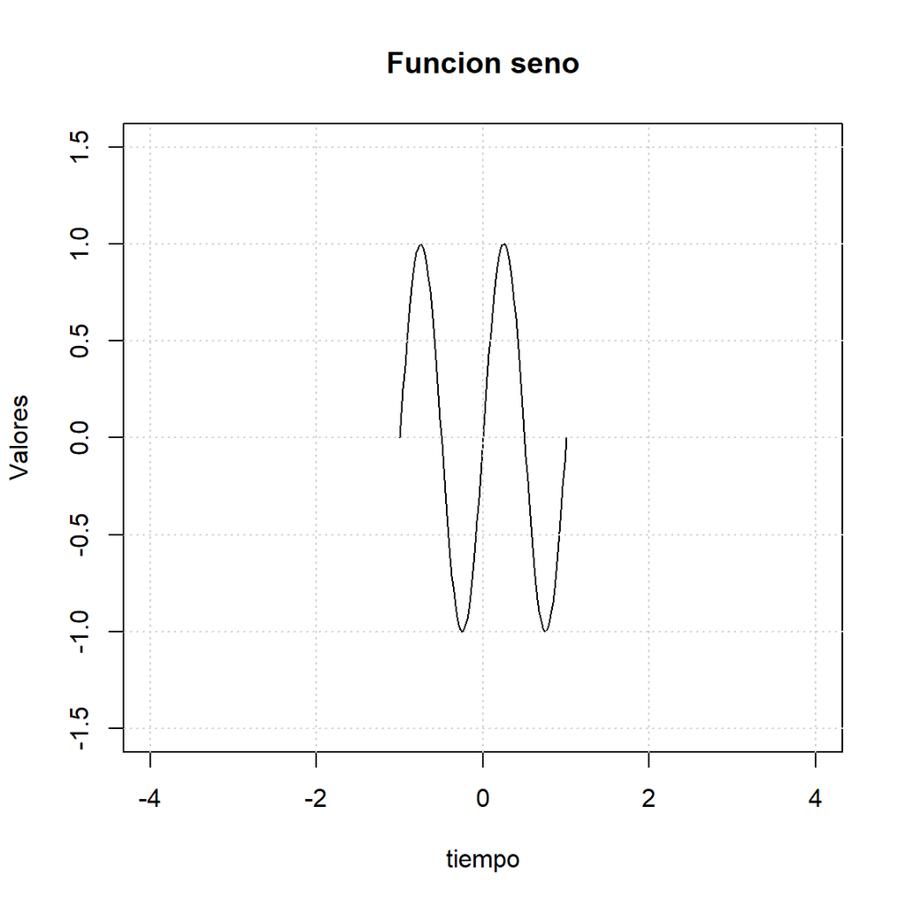

```r
t  <- seq(-1, 1, length=100)
ft   <- sin(2*pi*t)           # Se calcula la funcion seno a partir de t
plot(t, ft, type="l", xlim=c(-4,4), ylim=c(-1.5,1.5), main="Funcion seno", xlab="tiempo", ylab="Valores")
grid()
```

`R` permite añadir gráficos o puntos mediante las funciones `lines()` y `points()`. El siguiente código ejemplifica lo anterior.

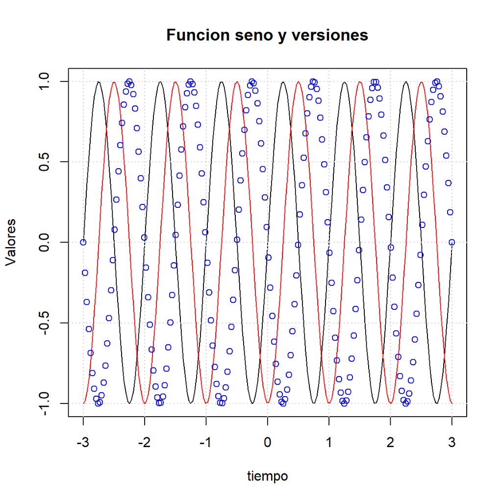

```r
t  <- seq(-3,3, length=200)
f1 <- sin(2*pi*(t))
f2 <- sin(2*pi*(t-1/4))
f3 <- sin(2*pi*(t-1/2))
plot(t,f1, type= "l", main="Funcion seno y versiones", xlab="tiempo", ylab="Valores")
grid()
lines(t,f2, col="red")
points(t,f3,col="blue")
```

De igual manera se pueden definir funciones por tramos con el comando `ifelse()`, por ejemplo grafiquemos la siguiente función:

$$f(t) = \begin{cases}
2+t & \; -2<t<-1\\
1 & \; -1<t<1\\
2-t & \;1<t<2\\
0 & \; \mbox{resto}
\end{cases}$$

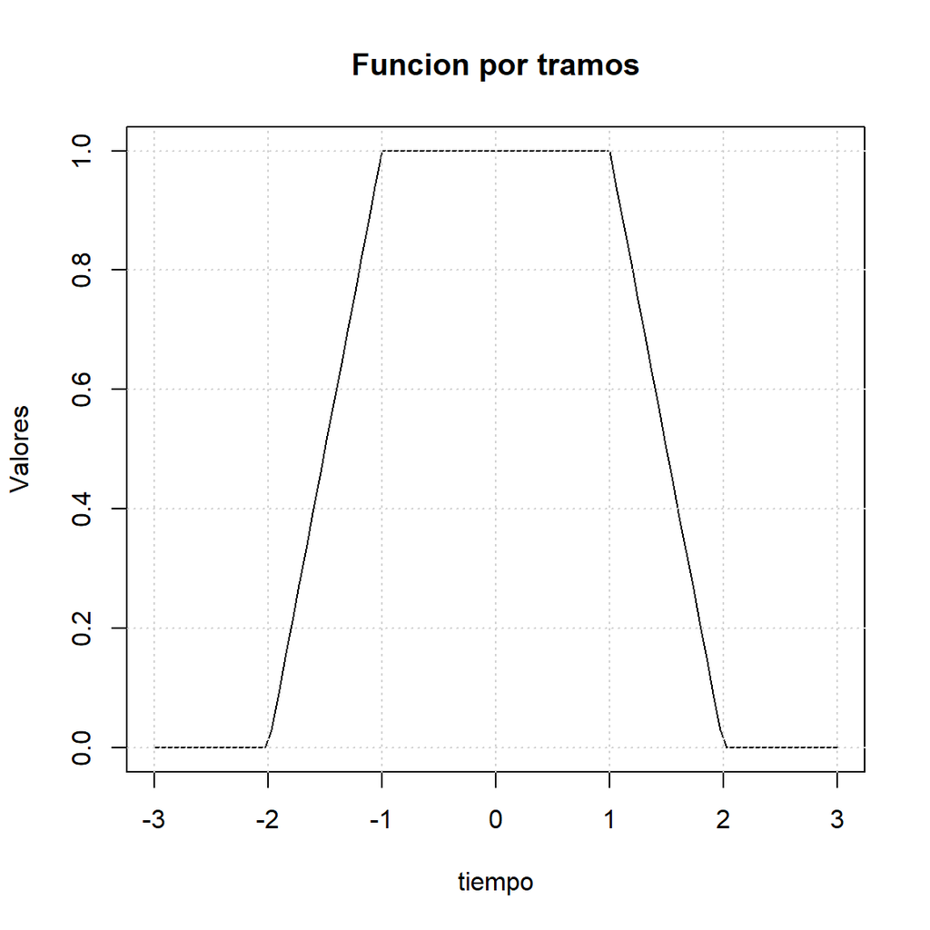

```r
t <- seq(-3,3, length=100)
ft <- ifelse(t> -2 & t < -1, 2+t, ifelse(t>= -1 & t <= 1, 1, ifelse(t>1 & t< 2, 2-t, 0)))
plot(t, ft, type = "l", main="Funcion por tramos", xlab="tiempo", ylab="Valores")
grid()
```

### Ejercicios:

Graficar las siguientes funciones:

$$f(t) = \begin{cases}
1 & \; t>0\\
0 & \; \mbox{resto}
\end{cases}$$

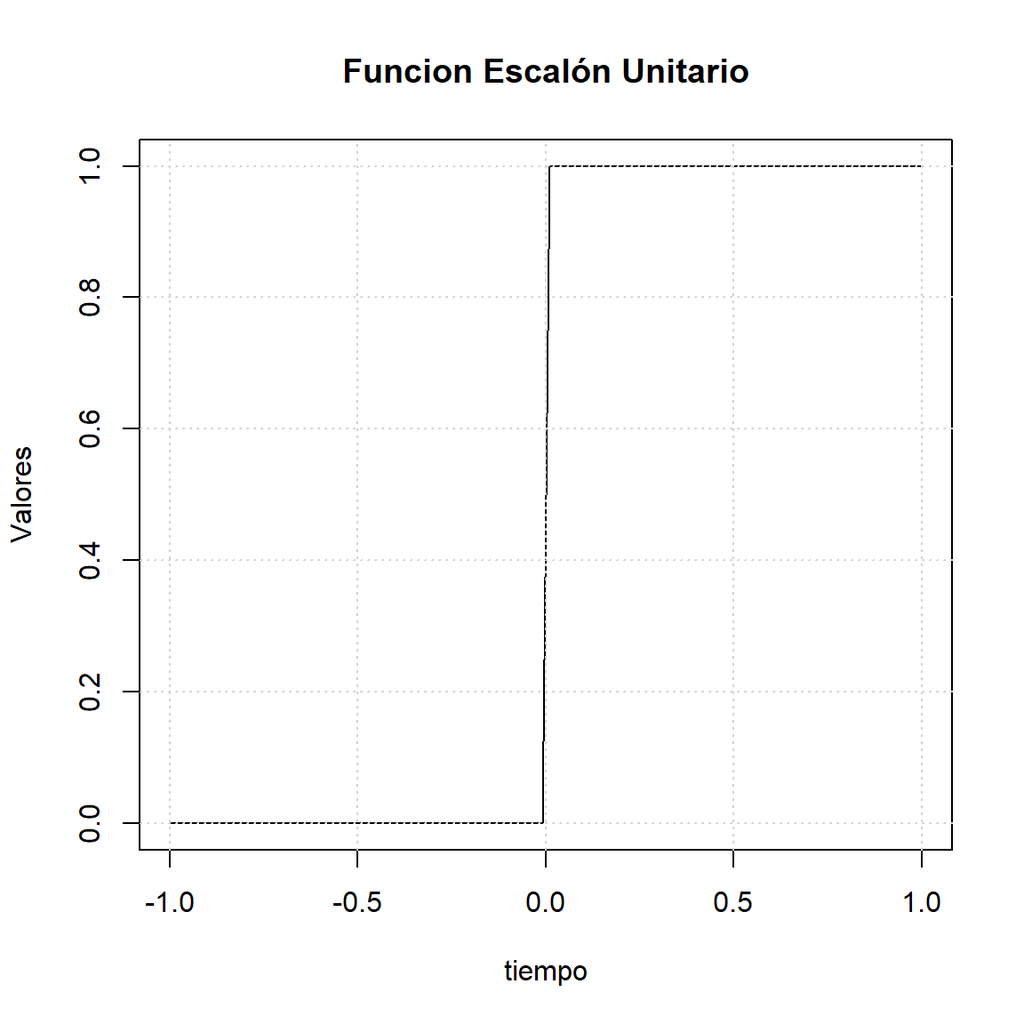

```r
t <- seq(-1, 1, length=100)
ft <- ifelse(t > 0, 1, 0)
plot(t, ft, type = "l", main="Funcion Escalón Unitario", xlab="tiempo", ylab="Valores")
grid()
```

$$f(t) = \begin{cases}
1+t & \; -1<t<0\\
1-t & \; 0 \le t<1\\
0 & \; \mbox{resto}
\end{cases}$$

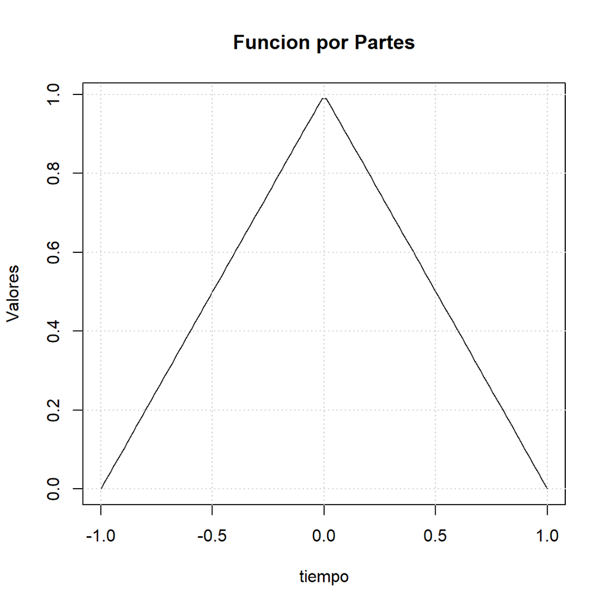

```r
t <- seq(-1, 1, length=100)
ft <- ifelse(t> -1 & t < 0, 1+t, ifelse(t>= 0 & t < 1, 1-t, 0))
plot(t, ft, type = "l", main="Funcion por Partes", xlab="tiempo", ylab="Valores")
grid()
```

$$f(t) = \begin{cases}
\mbox{e}^{-2t} & \; 0<t<2\\
1+t & \; -1<t<0\\
0 & \; \mbox{resto}
\end{cases}$$

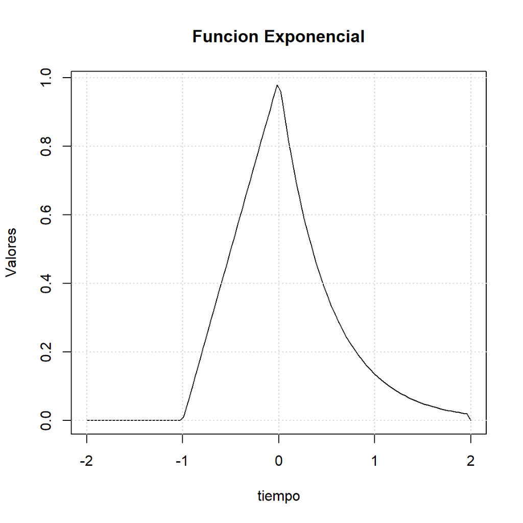

```r
t <- seq(-2, 2, length=100)
ft <- ifelse(t> 0 & t < 2, exp(-2 * t), ifelse(t> -1 & t < 0, 1+t, 0))
plot(t, ft, type = "l", main="Funcion Exponencial", xlab="tiempo", ylab="Valores")
grid()
```

# Gráficos 3D

Los gráficos en 3D permiten visualizar funciones del tipo: $f(x,y)$, donde $x$ e $y$ representan variables independientes. Como ejemplo veamos la forma en la cual `R` grafica la siguiente funci?n $f(x,y) = \sqrt{16-4x^2-y^2}$:

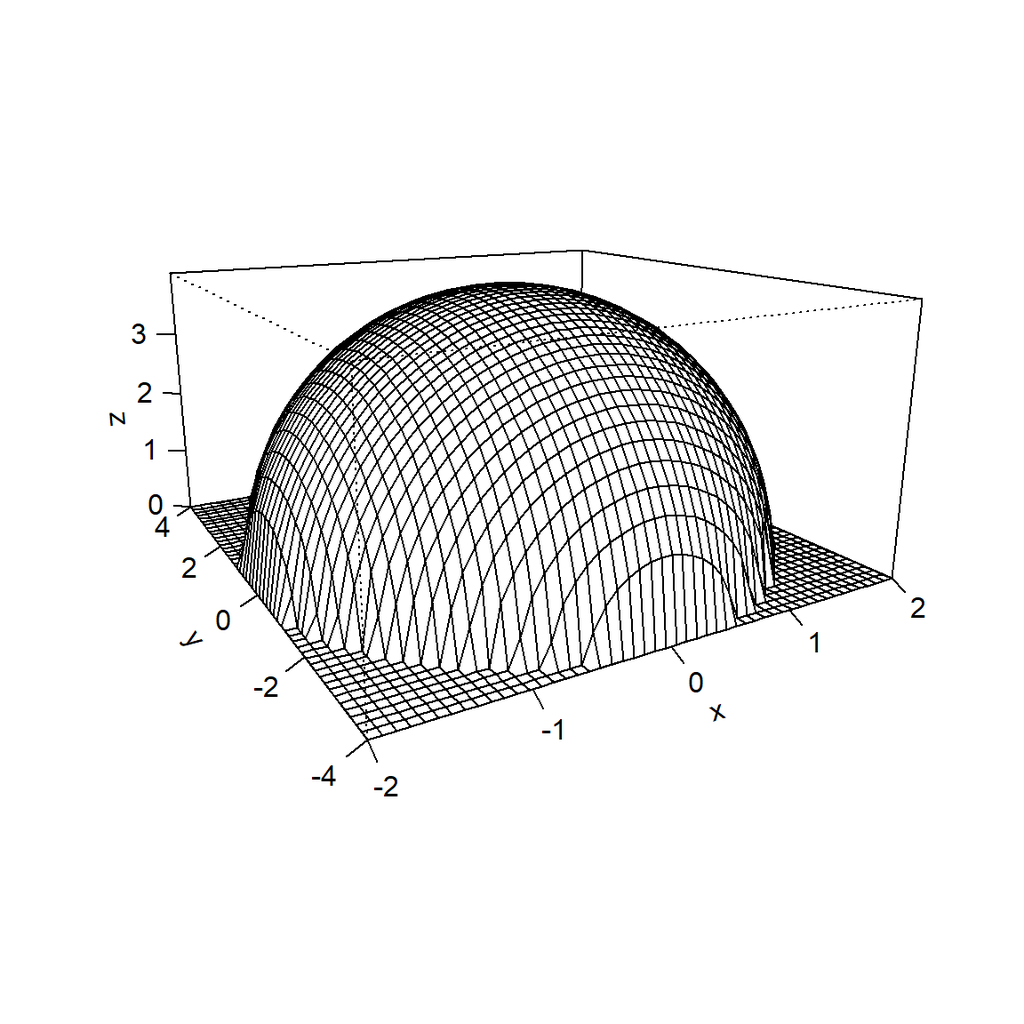

```r
x <- seq(-2,2,length=50)
y <- seq(-4,4, length=50)
z <- outer(x,y,function(x,y) sqrt(16-4*x^2-y^2))
z[is.na(z)] <- 0
persp(x,y,z, theta=-30, expand=0.5,ticktype = "detailed")
```

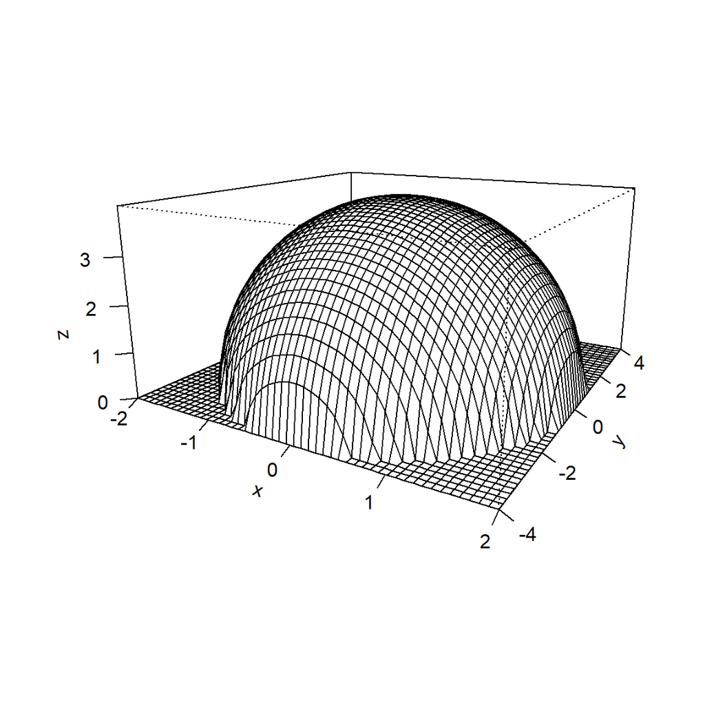

```r
persp(x,y,z, theta=30, expand=0.5, ticktype = "detailed")
```

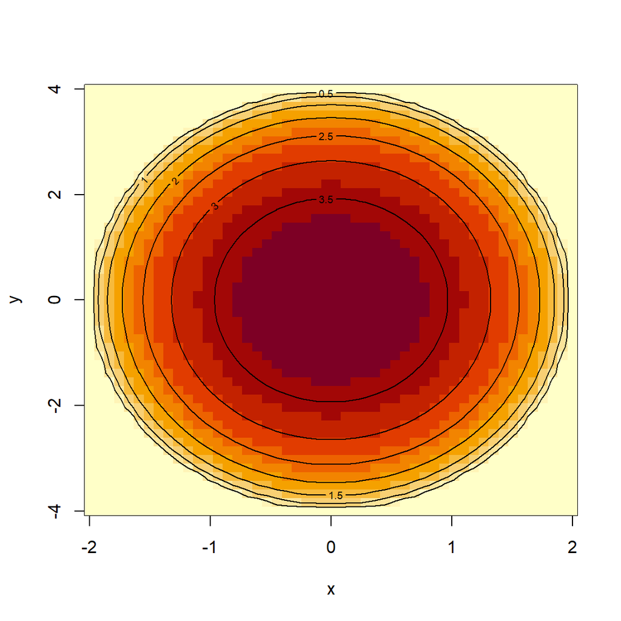

```r
image(x,y,z)
contour(x,y,z, add=TRUE)
```

Ejemplos: Ahora veamos la manera de hacerla con más funciones.

#### Ahora para la función $z = y^2-x^2$

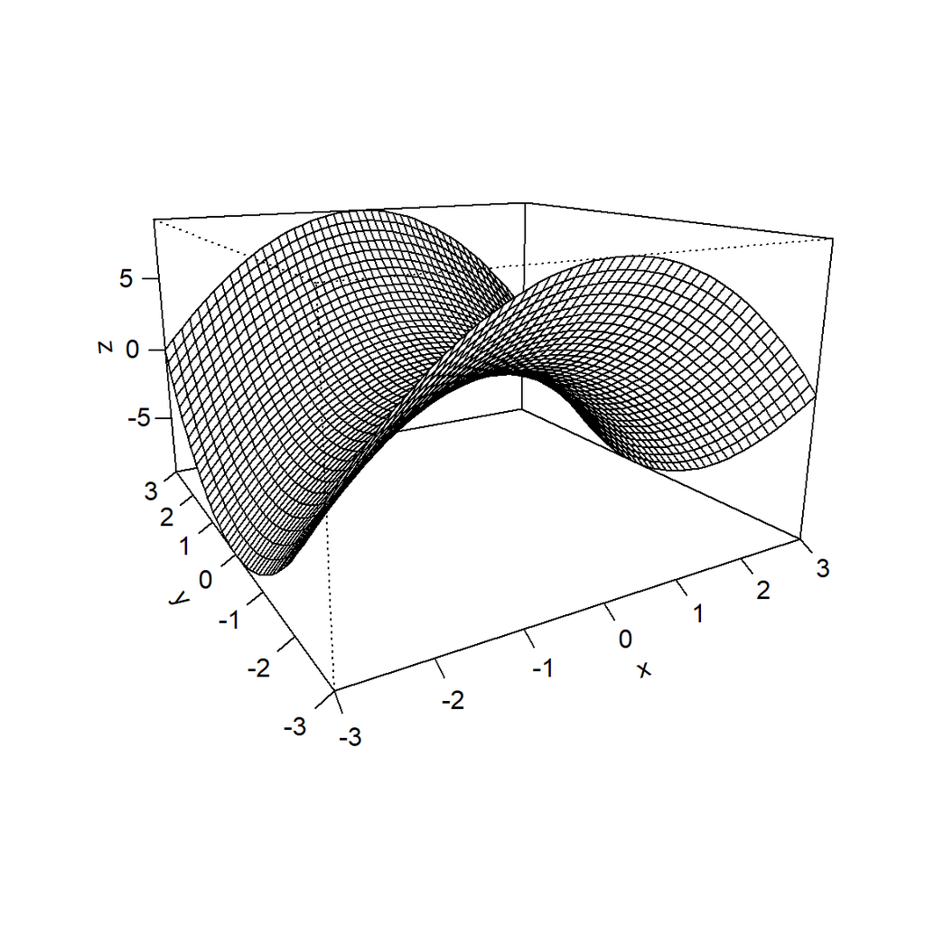

```r
x <- seq(-3,3,length=50)
y <- seq(-3,3, length=50)
z <- outer(x,y,function(x,y) y^2-x^2)
persp(x,y,z, theta=-30, expand=0.6, ticktype = "detailed")
```

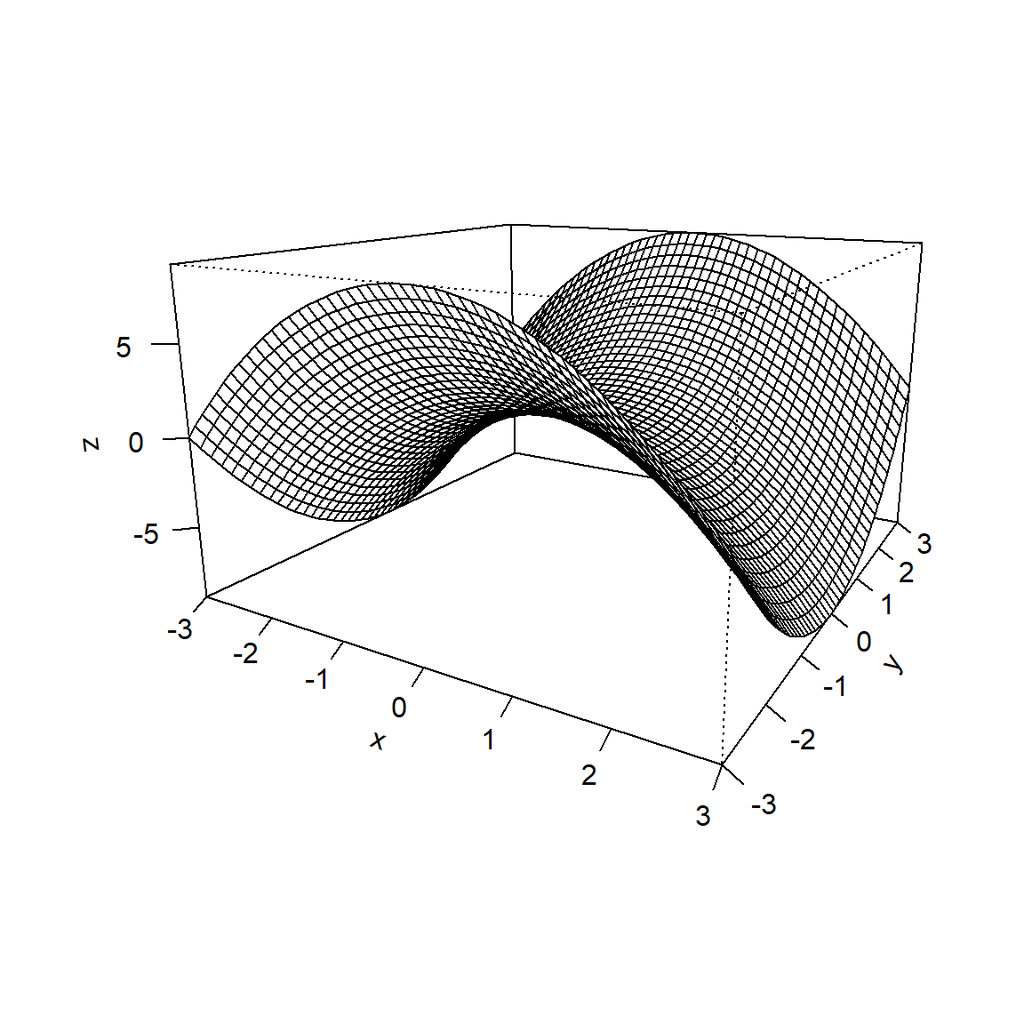

```r
persp(x,y,z, theta=30, expand=0.6, ticktype = "detailed")
```

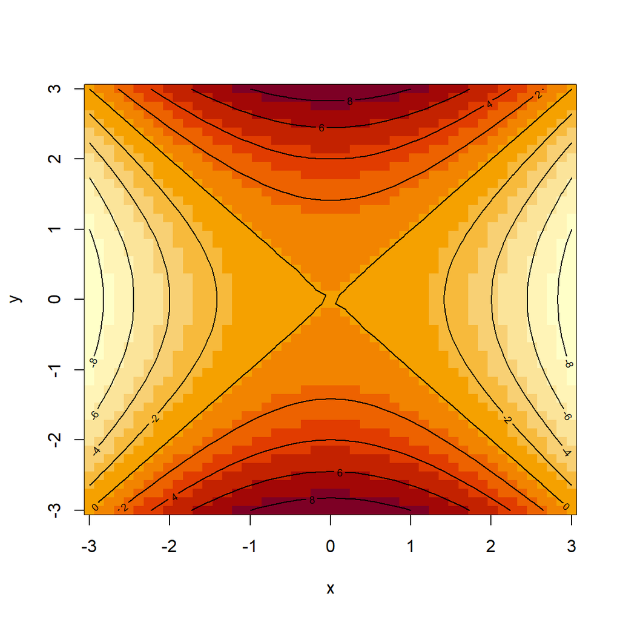

```r
image(x,y,z)
contour(x,y,z, add=TRUE)
```

#### Ahora para la función $f(x,y)= (2+x^2-y^2) \mbox{e}^{1-x^2-(y^2)/4}$

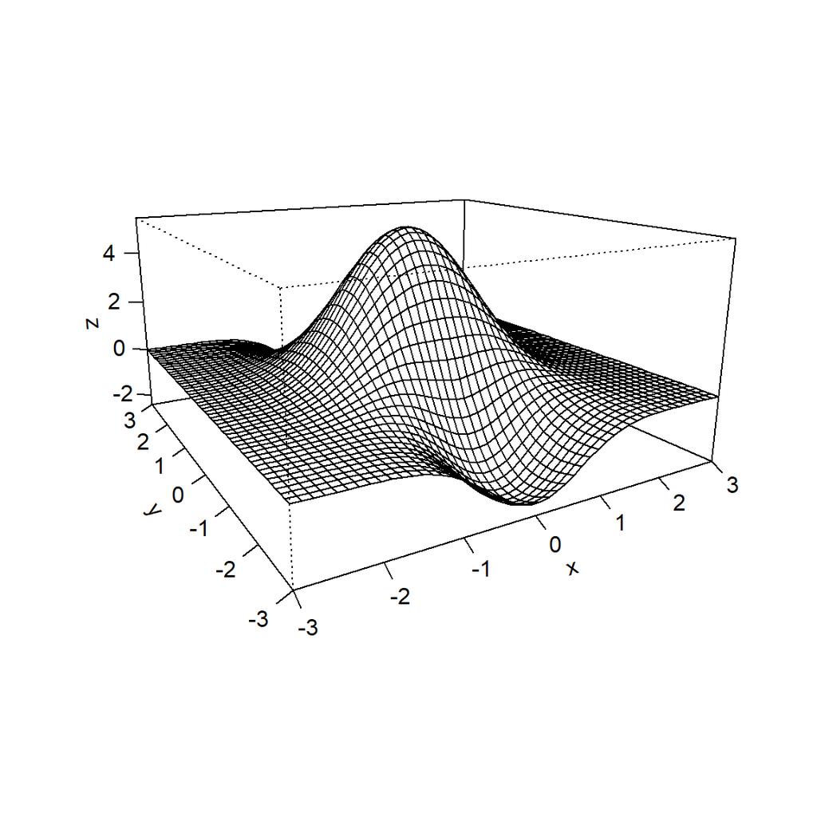

```r
x <- seq(-3,3,length=50)
y <- seq(-3,3, length=50)
z <- outer(x,y,function(x,y) (2-y^2+x^2)*exp(1-x^2-(y^2)/4))
persp(x,y,z, theta=-30, expand=0.5, ticktype = "detailed")
```

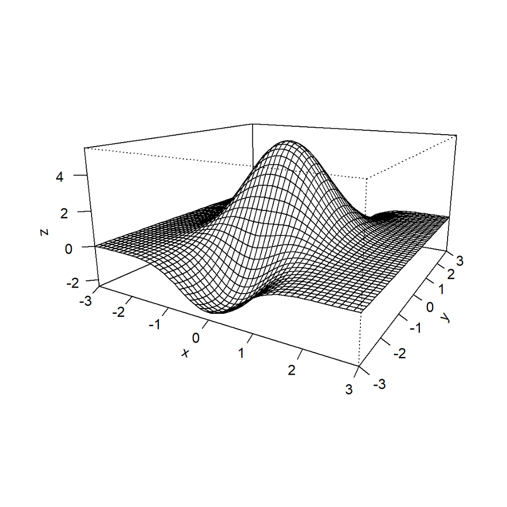

```r
persp(x,y,z, theta=30,expand=0.5,ticktype = "detailed")
```

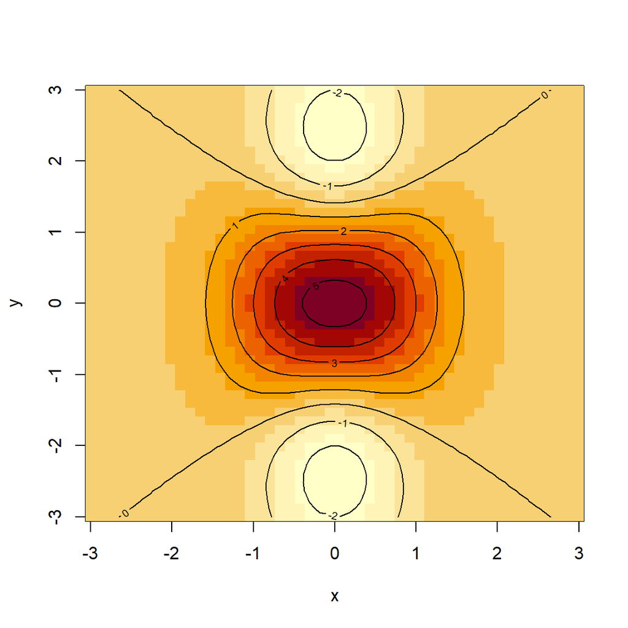

```r
image(x,y,z)
contour(x,y,z, add=TRUE)
```

#### Ejercicios:

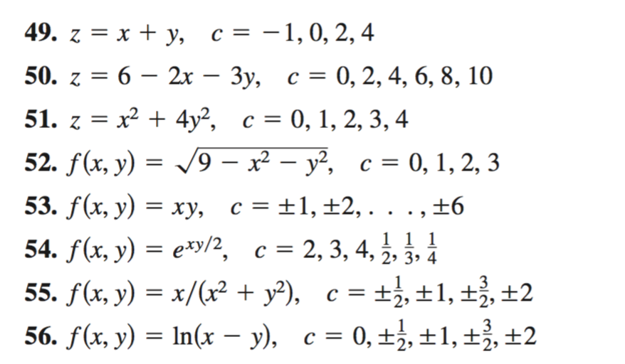

Ejercicios para graficar superficies y contornos en R.

#### Ejercicio 49:

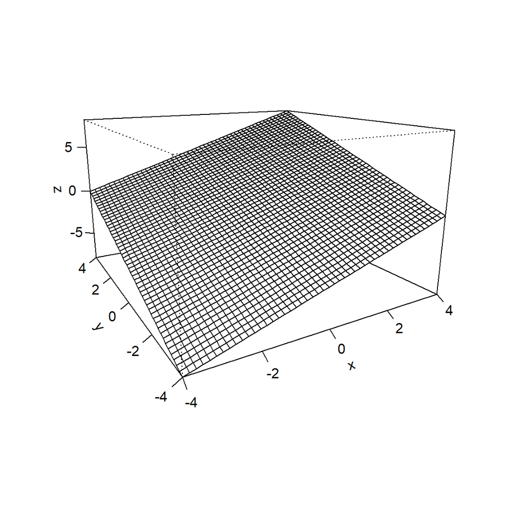

```r
x <- seq(-4,4,length=50)
y <- seq(-4,4, length=50)
z <- outer(x,y,function(x,y) x+y)
persp(x,y,z, theta=-30, expand=0.6, ticktype = "detailed")
```

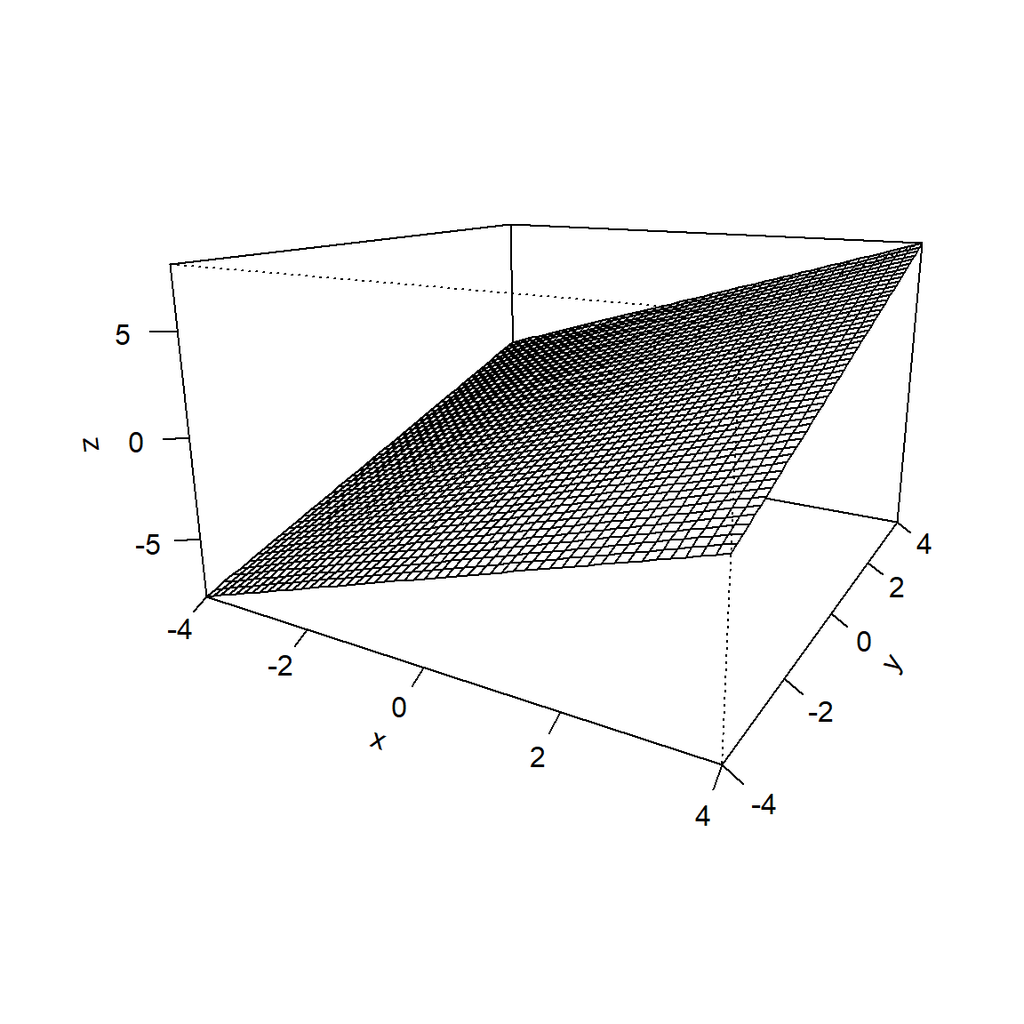

```r
persp(x,y,z, theta=30, expand=0.6, ticktype = "detailed")
```

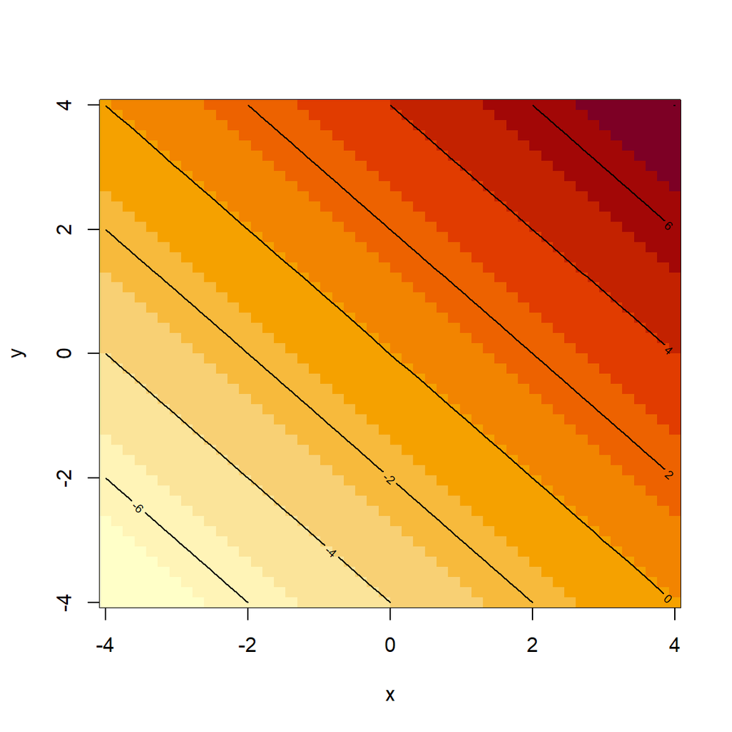

```r
image(x,y,z)
contour(x,y,z, add=TRUE)
```

#### Ejercicio 50:

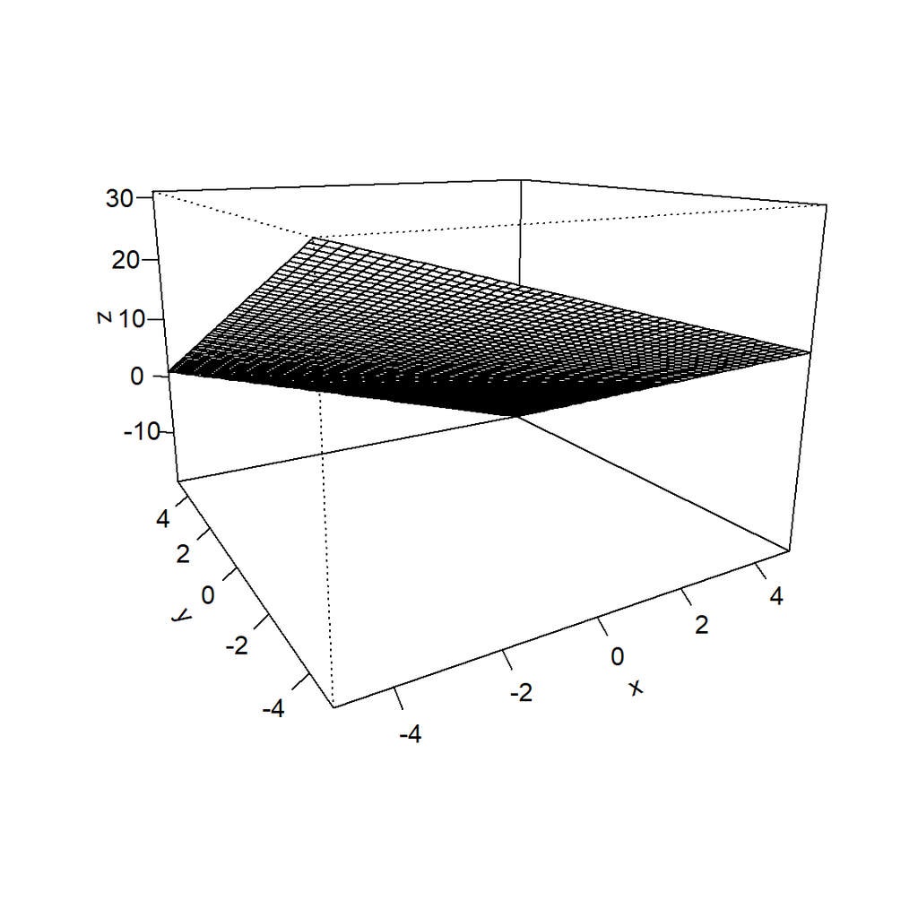

```r
x <- seq(-5,5,length=50)
y <- seq(-5,5, length=50)
z <- outer(x,y,function(x,y) 6- 2*x - 3*y)
persp(x,y,z, theta=-30, expand=0.7, ticktype = "detailed")
```

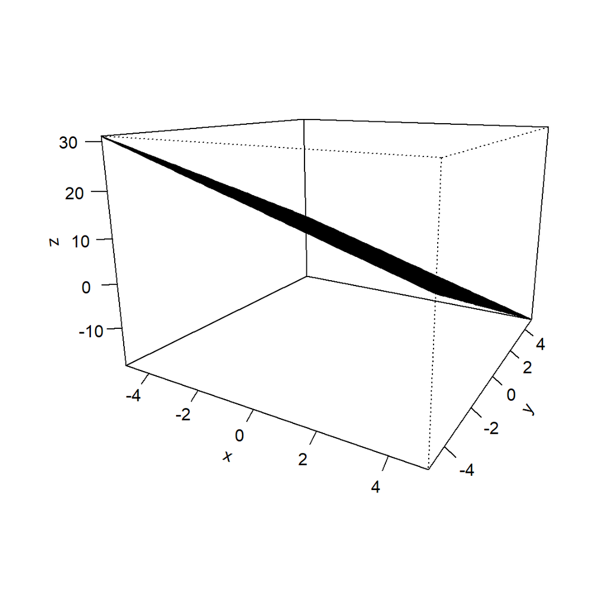

```r
persp(x,y,z, theta=30, expand=0.7, ticktype = "detailed")
```

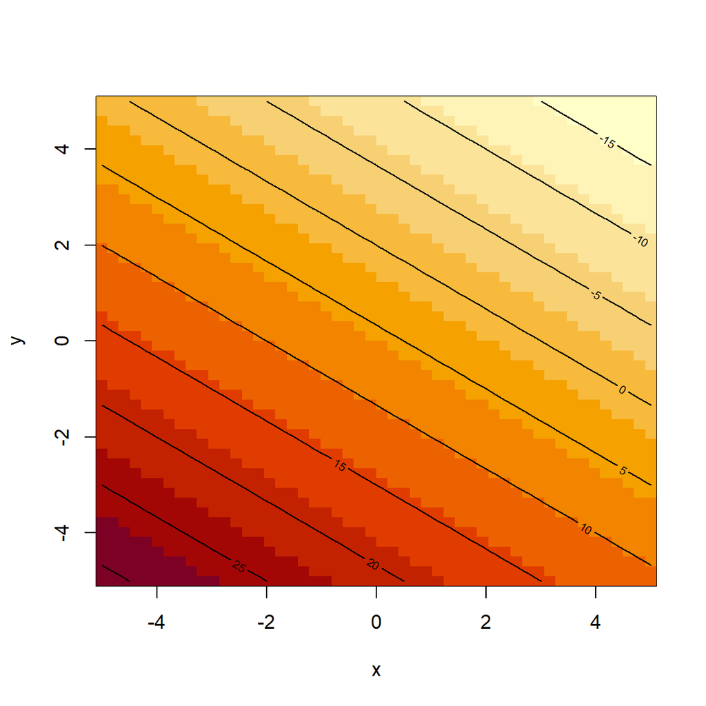

```r
image(x,y,z)
contour(x,y,z, add=TRUE)
```

#### Ejercicio 51:

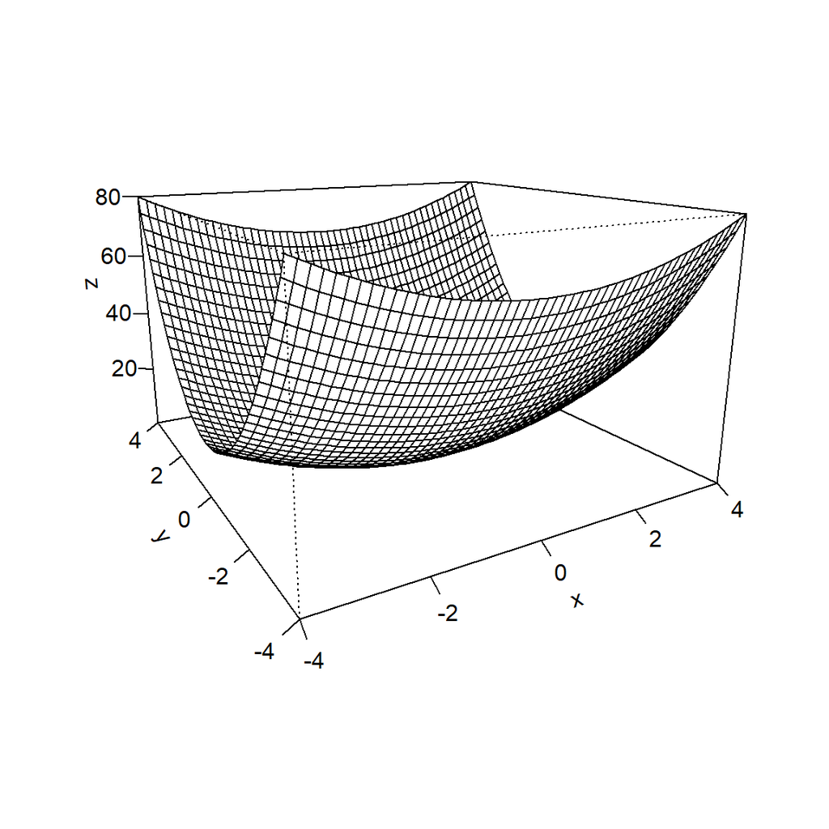

```r
x <- seq(-4,4,length=50)
y <- seq(-4,4, length=50)
z <- outer(x,y,function(x,y) x^2 + 4*(y^2))
persp(x,y,z, theta=-30, expand=0.6, ticktype = "detailed")
```

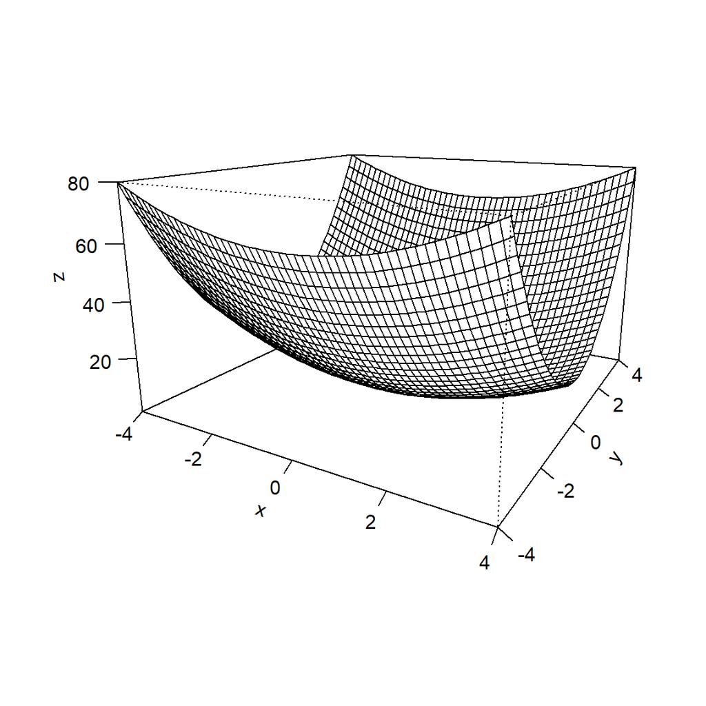

```r
persp(x,y,z, theta=30, expand=0.6, ticktype = "detailed")
```

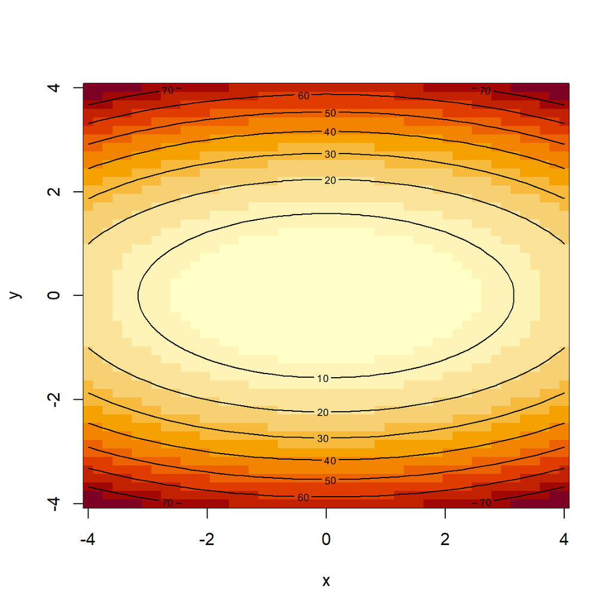

```r
image(x,y,z)
contour(x,y,z, add=TRUE)
```

#### Ejercicio 52:

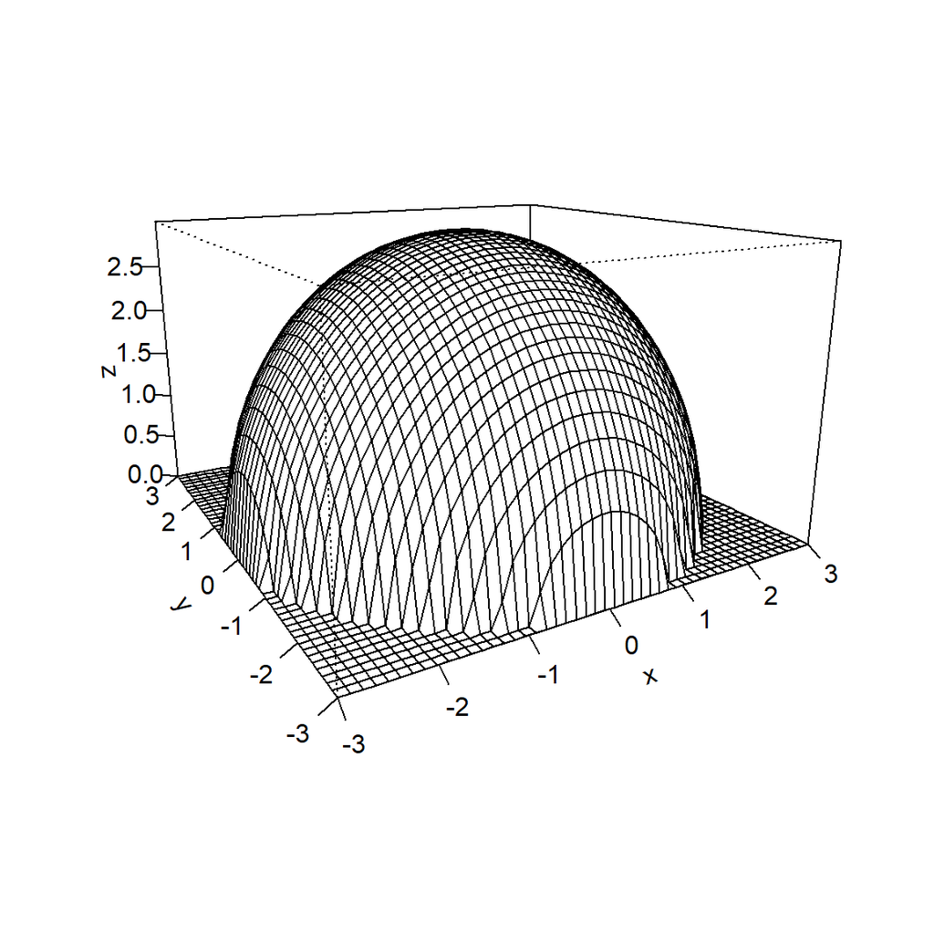

```r
x <- seq(-3,3,length=50)
y <- seq(-3,3, length=50)
z <- outer (x,y,function(x,y) (sqrt(9 - x^2 - y^2)))
z[is.na(z)] <- 0
persp(x,y,z, theta=-30, expand=0.6, ticktype = "detailed")
```

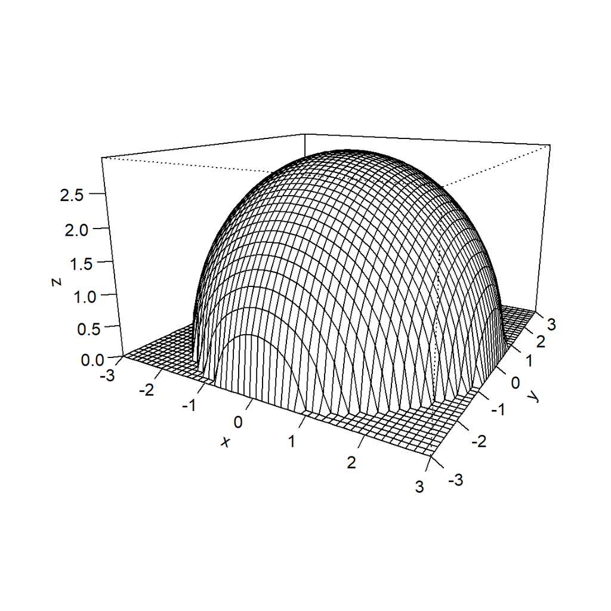

```r
persp(x,y,z, theta=30, expand=0.6, ticktype = "detailed")
```

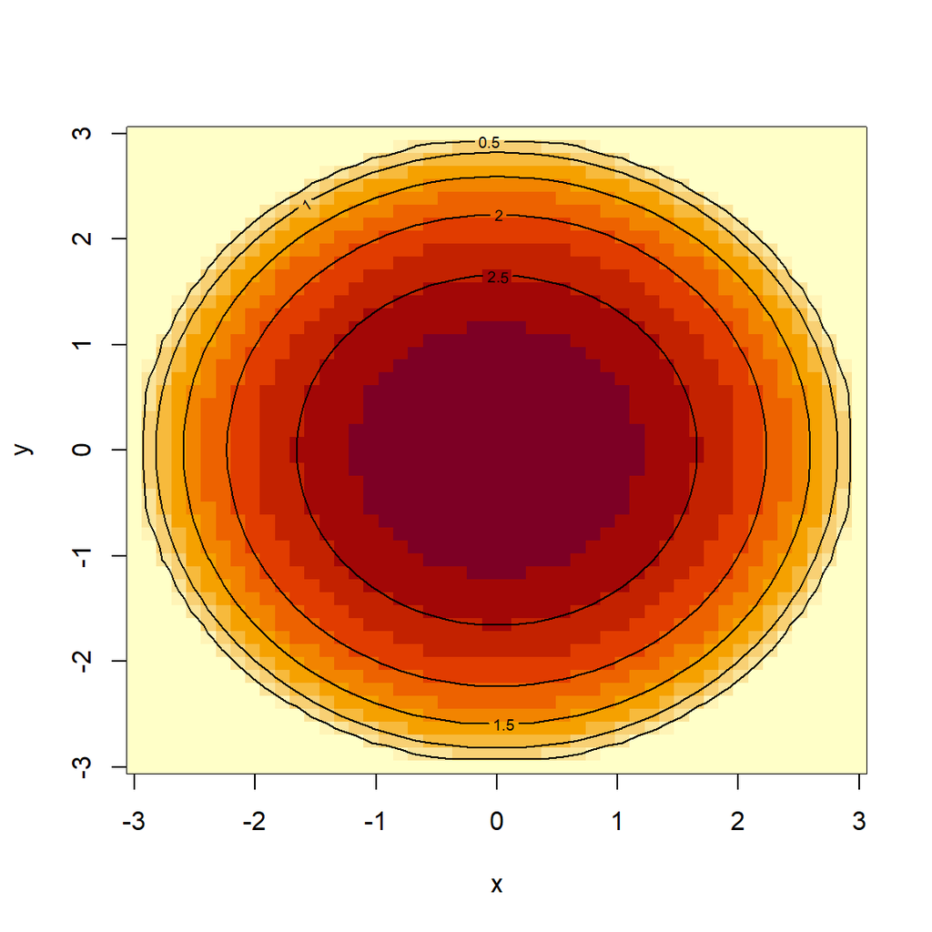

```r
image(x,y,z)
contour(x,y,z, add=TRUE)
```

#### Ejercicio 53:

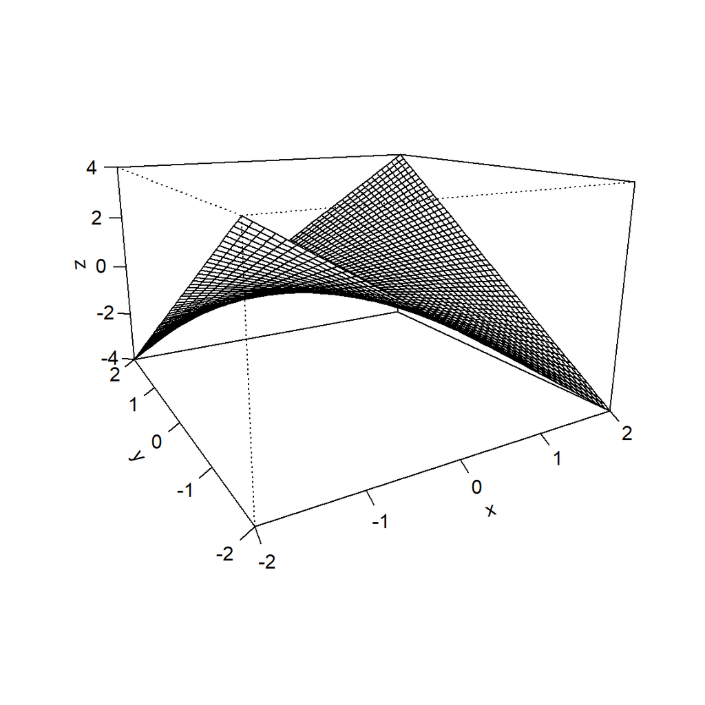

```r
x <- seq(-2,2,length=50)
y <- seq(-2,2, length=50)
z <- outer(x,y,function(x,y) x*y)
z[is.na(z)] <- 0
persp(x,y,z, theta=-30, expand=0.6, ticktype = "detailed")
```

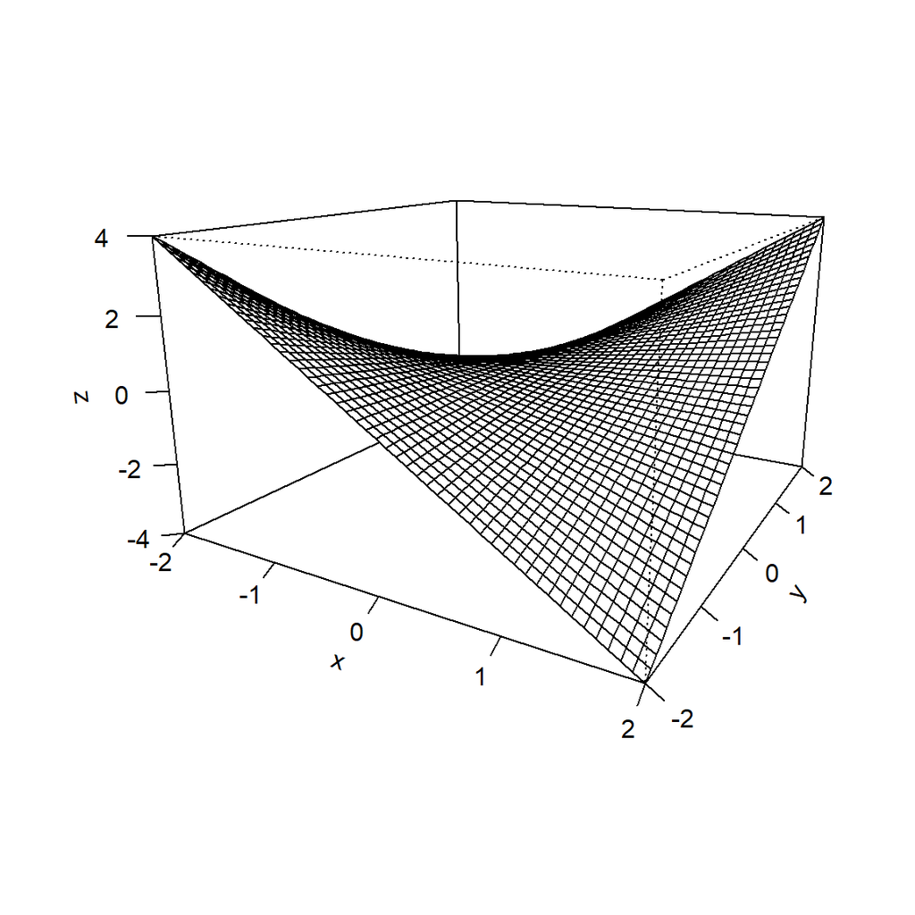

```r
persp(x,y,z, theta=30, expand=0.6, ticktype = "detailed")
```

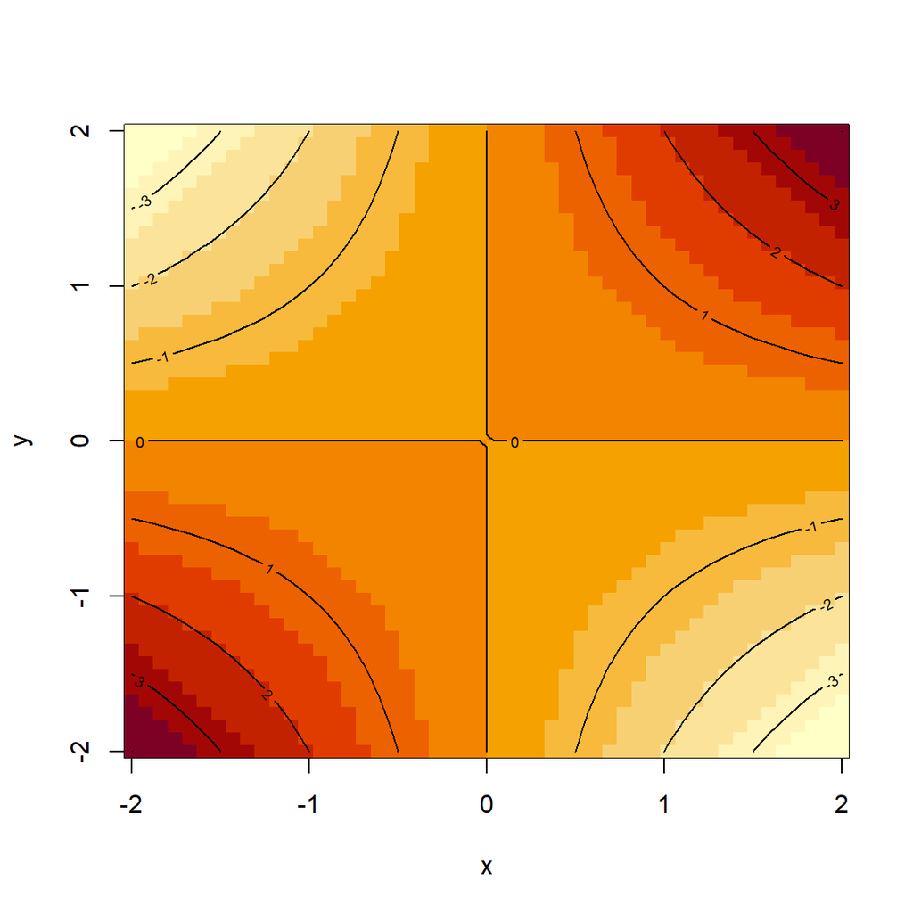

```r
image(x,y,z)
contour(x,y,z, add=TRUE)
```